# Schmidt_Emily_TP4

Emily Schmidt

2024-01-06

```r
# Clear the database
rm(list=ls())
graphics.off()
shell("cls")
```

```r
# Load libraries
library(fpp2)
library(fpp3)
library(ggplot2)
```

# 1 Exercise 3

In this exercise we replace the normal simulation by bootstrap. For this purpose, use the code seen in the exercise 2.5 adapted for the matrix case.  
**Hint**: use sample on the residuals.  
Compute statistics from the exercise 2.6. What does bootstrap mean taking into account the context of the exercise? Why and when it can be applied? Comment on your results.

```
## Time Series:
## Start = 1
## End = 6
## Frequency = 1
##   Paperback Hardcover
## 1       199       139
## 2       172       128
## 3       111       172
## 4       209       139
## 5       161       191
## 6       119       168
```

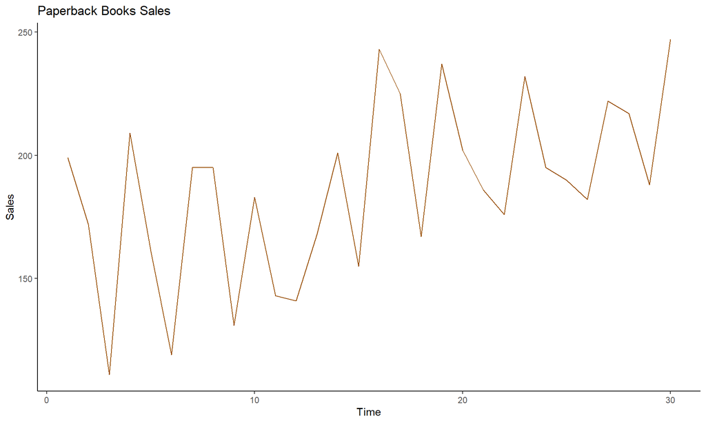

Paperback books appear to have a positive trend with no seasonality. Seasonality does not exist because there is not a consistent pattern in relation to time. Instead, it is more random. Visually, we can possibly also rule out a multiplicative model because the amplitudes do not continue to widen and there is not an exponential growth. Since the previous exercise used an additive and damped Holt model (A, Ad, N), this will most likely be the best method. According to the ETS Table, the model’s components are:

- $y_t = l_{t-1} + {\phi}b_{t-1} + {\epsilon}_t$
- $l_t = l_{t-1} + {\phi}b_{t-1} + {\alpha}{\epsilon}_t$
- $b_t = {\phi}b_{t-1} + {\beta}{\epsilon}_t$

```r
# ETS model, "AAdN"
model_AAdN <- books_tsibble |>
  model(
    `Holt` = ETS(Paperback ~ error("A") + trend("Ad") + season("N")))

components(model_AAdN) |> print(n=31) # last observation to use in the forecast
```

```
## # A dable: 31 x 6 [1]
## # Key:     .model [1]
## # :        Paperback = lag(level, 1) + 0.97999996798076 * lag(slope, 1) +
## #   remainder
##    .model  Time Paperback level slope remainder
##    <chr>  <dbl>     <int> <dbl> <dbl>     <dbl>
##  1 Holt       0        NA  172. 1.84      NA
##  2 Holt       1       199  174. 1.80      25.4
##  3 Holt       2       172  176. 1.76      -4.22
##  4 Holt       3       111  176. 1.72     -66.8
##  5 Holt       4       209  178. 1.69      31.7
##  6 Holt       5       161  179. 1.66     -19.0
##  7 Holt       6       119  179. 1.62     -62.0
##  8 Holt       7       195  181. 1.59      14.4
##  9 Holt       8       195  183. 1.55      12.4
```

[output cut: 22 more lines]

```r
fabletools::accuracy(model_AAdN)
```

```
## # A tibble: 1 × 10
##   .model .type       ME  RMSE   MAE   MPE  MAPE  MASE RMSSE   ACF1
##   <chr>  <chr>    <dbl> <dbl> <dbl> <dbl> <dbl> <dbl> <dbl>  <dbl>
## 1 Holt   Training -4.28  31.9  26.8 -5.93  16.0 0.675 0.675 -0.162
```

```r
report(model_AAdN)
```

```
## Series: Paperback
## Model: ETS(A,Ad,N)
##   Smoothing parameters:
##     alpha = 0.03259223
##     beta  = 0.0001000242
##     phi   = 0.98
##
##   Initial states:
##      l[0]     b[0]
##  171.8317 1.835088
##
##   sigma^2:  1220.294
##
##      AIC     AICc      BIC
## 321.7717 325.4239 330.1789
```

When comparing models, the analyst should try to achieve the lowest AIC, AICc, and RMSE. In terms of forecasting, a minimum value for the Akaike’s Information Criterion is best. Additionally, the following smoothing parameters are:

- $\alpha$: The estimated smoothing coefficient is 0.03259223. As the value is closer to 0, this means that more weight is given to observations from the more distant past.
- $\beta$: The estimated smoothing coefficient for the slope is 0.0001000242. This means that the slope does not change often even if there are slight changes.
- $\phi$: The $\phi$ represents the dampened effect. The value is 0.98, which suggests that the damped model is not able to be distinguished from a non-damped model.

To ensure that this is the optimal choice, we run model() to see what method is produced. It suggests using an additive SES model (A, N, N), but this is problematic since we have already identified that there is a trend. Even though this model has a better AIC, intuitively, we will stick with the first model presented, Holt’s (A, Ad, N).

```
## Series: Paperback
## Model: ETS(A,N,N)
##   Smoothing parameters:
##     alpha = 0.168421
##
##   Initial states:
##      l[0]
##  170.8464
##
##   sigma^2:  1212.315
##
##      AIC     AICc      BIC
## 318.9747 319.8978 323.1783
```

```
## # A tibble: 1 × 10
##   .model        .type       ME  RMSE   MAE   MPE  MAPE  MASE RMSSE   ACF1
##   <chr>         <chr>    <dbl> <dbl> <dbl> <dbl> <dbl> <dbl> <dbl>  <dbl>
## 1 Unknown_Model Training  7.18  33.6  27.8 0.473  15.6 0.702 0.712 -0.212
```

```
## # A dable: 31 x 5 [1]
## # Key:     .model [1]
## # :        Paperback = lag(level, 1) + remainder
##    .model         Time Paperback level remainder
##    <chr>         <dbl>     <int> <dbl>     <dbl>
##  1 Unknown_Model     0        NA  171.     NA
##  2 Unknown_Model     1       199  176.     28.2
##  3 Unknown_Model     2       172  175.     -3.59
##  4 Unknown_Model     3       111  164.    -64.0
##  5 Unknown_Model     4       209  172.     44.8
##  6 Unknown_Model     5       161  170.    -10.8
##  7 Unknown_Model     6       119  161.    -50.9
##  8 Unknown_Model     7       195  167.     33.6
##  9 Unknown_Model     8       195  172.     28.0
## 10 Unknown_Model     9       131  165.    -40.7
## # ℹ 21 more rows
```

Identifying the necessary parameters from Holt’s model to be used in bootstrapping.

```
## Series: Paperback
## Model: ETS(A,Ad,N)
##   Smoothing parameters:
##     alpha = 0.03259223
##     beta  = 0.0001000242
##     phi   = 0.98
##
##   Initial states:
##      l[0]     b[0]
##  171.8317 1.835088
##
##   sigma^2:  1220.294
##
##      AIC     AICc      BIC
## 321.7717 325.4239 330.1789
```

## 1.1 Forecast Sales

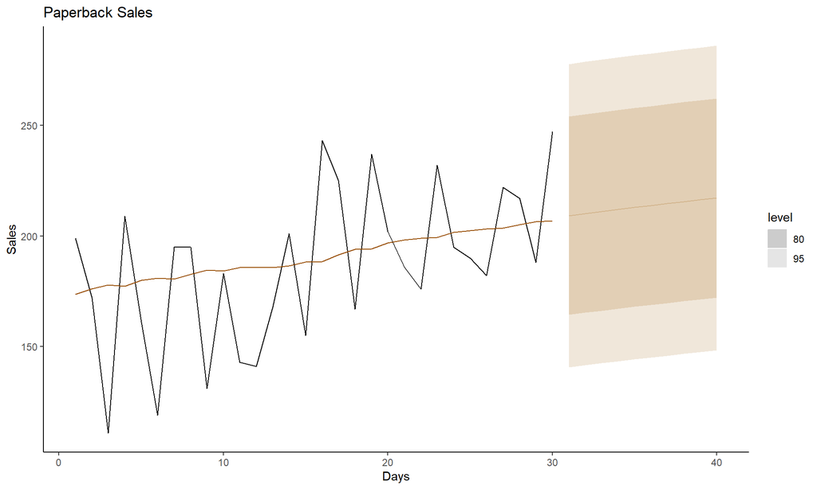

The graph shows a 10-day forecast for paperback book sales. Within the shaded portion to the right, the reader will see smoothed prediction intervals for this specific time period. These PIs give an interval within which $y_t$ is expected to lie within a certain probability. Typically, the 80% and 95% intervals are used. This statistical tool is helpful because it expresses the uncertainty in the forecast. It is much clearer how much is unknown with the associated forecast. In addition, the variance appears to be increasing with time.

**Prediction interval**: $\hat{y}_{T+h|T}{\pm}{c}\hat{\sigma}_h$

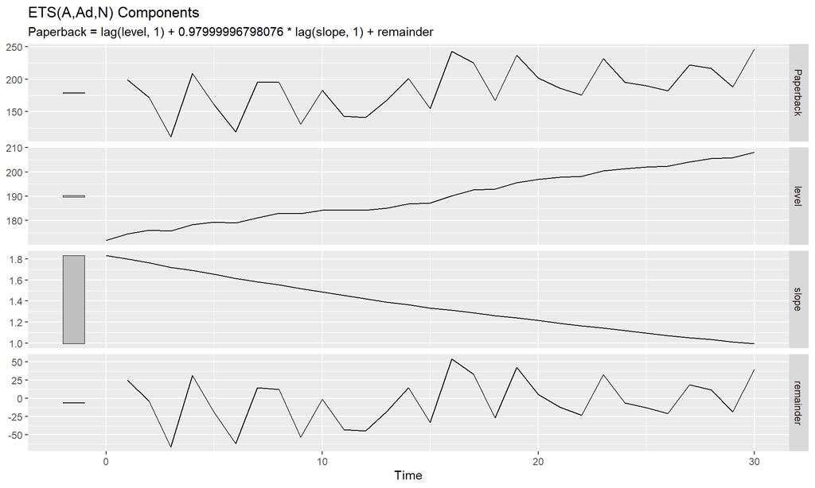

- **Level equation**: $l_t = {\alpha}y_t + (1 - {\alpha})(l_{t-1} +b_{t-1})$. This shows that $l_t$ is a weighted average of observation and the one-step-ahead training forecast for time $t$.
- **Trend equation**: This shows that $b_t$ is a weighted average of the estimated trend at time $t$ based on $l_t - l_{t-1}$ and $b_{t-1}$, the previous estimate of the trend. For this model, the slope is trending downward due to the damped effect.
- **Remainder component**: Containing what is not included in the time series. It appears to be random and show no pattern.

## 1.2 Residuals

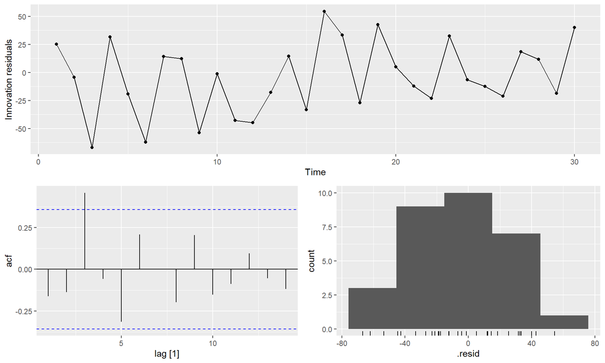

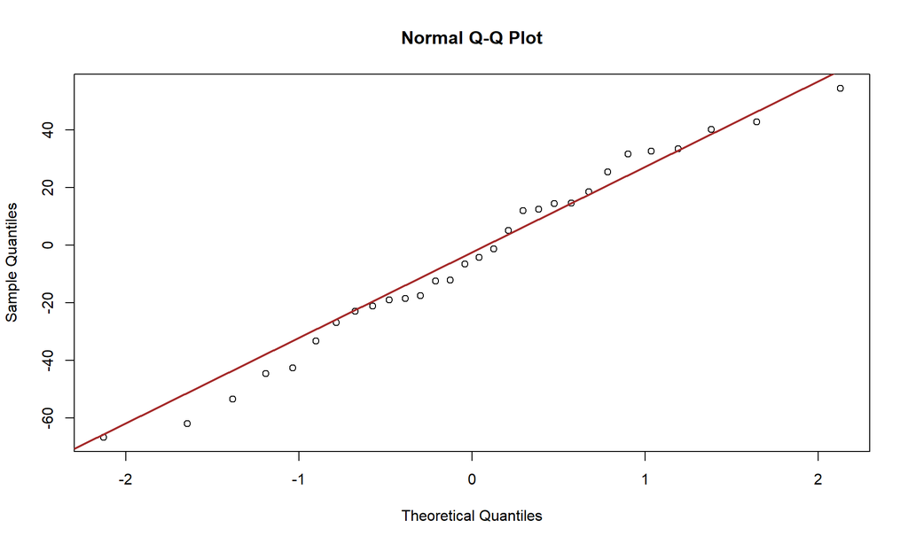

```
##
##  Shapiro-Wilk normality test
##
## data:  fitted_values$.resid
## W = 0.97847, p-value = 0.7835
```

Although checking residuals is not essential for forecasting, it makes calculating the prediction intervals much easier. Therefore, they should be checked to see if they are normally distributed. By using the gg_tsresiduals() function, it is seen that the errors do look slightly skewed. In addition, the correlogram shows that at lag 3 exceeds the dashed blue lines which indicate whether the correlations are significantly different from zero.

The QQ Plot of residuals appears to be possibly non-normal due to the points not being on the line. To determine if the residuals are normally distributed, we run a Shapiro-Walk test. The null hypothesis is that the errors are normally distributed. Since the p-value is greater than $\alpha$ at 0.05, there is not enough evidence to reject the null hypothesis. The residuals can be assumed to be normally distributed.

## 1.3 Bootstapping Method

According to Chapter 5.5, ‘When a normal distribution for the residuals is an unreasonable assumption, one alternative is to use bootstrapping, which only assumes that the residuals are uncorrelated with constant variance.’ Therefore, we release the assumption of normality and bootstrap instead of simulate.

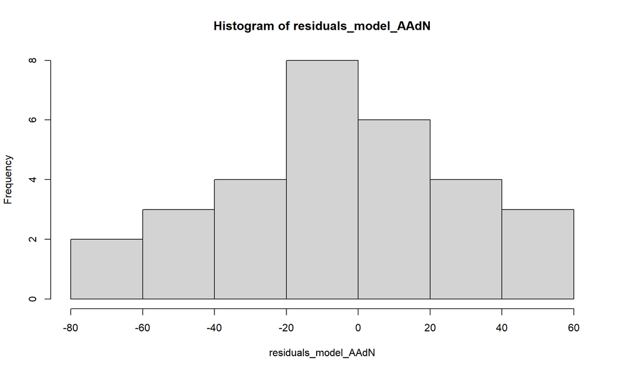

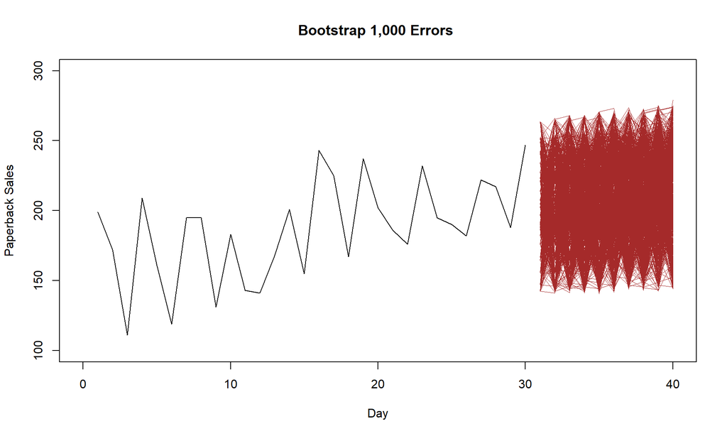

```
##           [,1]     [,2]     [,3]     [,4]     [,5]     [,6]     [,7]     [,8]
## 2.5%  142.3694 143.7942 145.4627 146.1672 147.2520 147.8314 149.9930 149.5954
## 97.5% 263.7044 262.6390 263.8891 263.9594 266.6038 266.3342 267.1332 263.3392
##           [,9]    [,10]
## 2.5%  150.4106 149.7587
## 97.5% 269.0634 270.5371
```

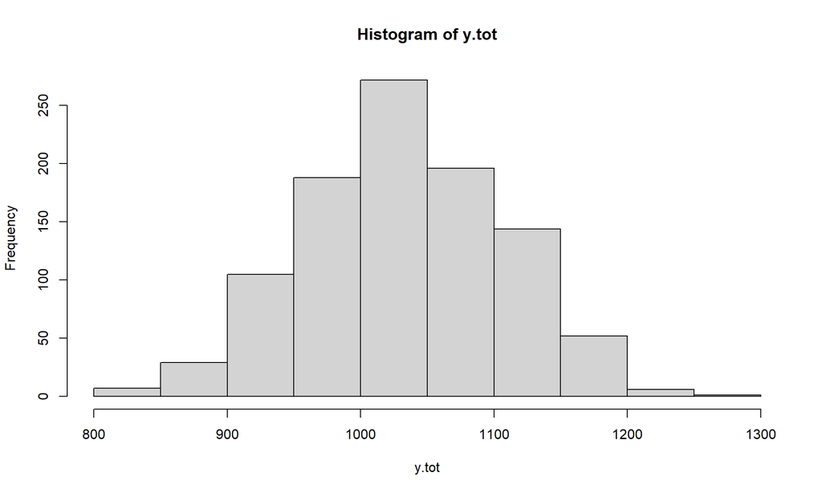

```
##    Min. 1st Qu.  Median    Mean 3rd Qu.    Max.
##   800.1   982.0  1031.1  1032.1  1085.1  1251.2
```

```
## [1] 0.17
```

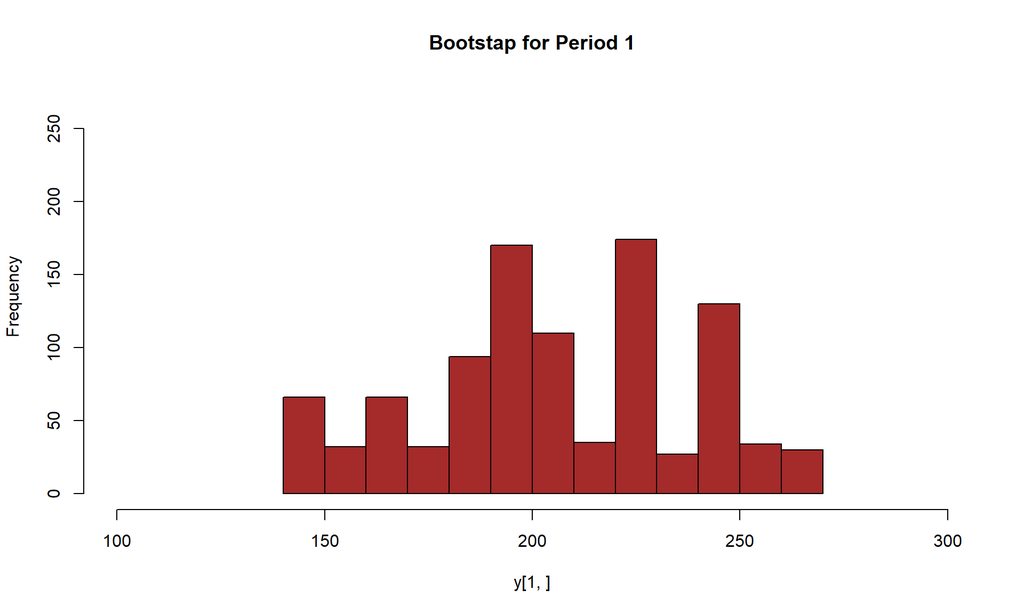

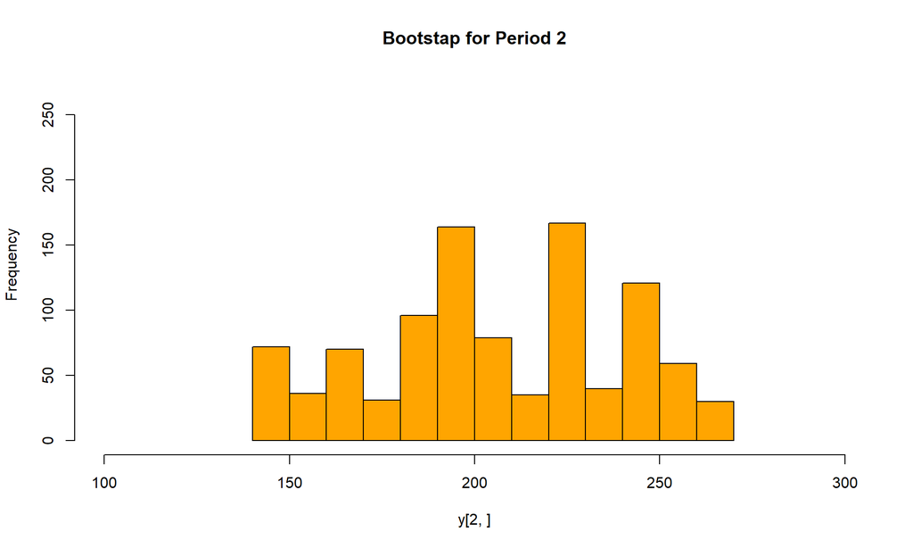

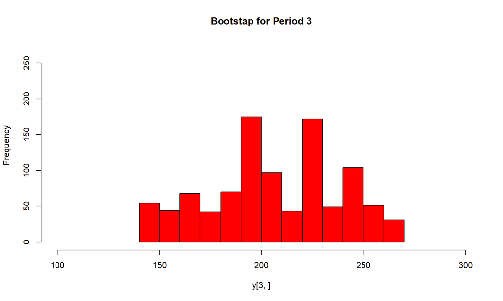

```
## [1] 0.137
```